# Introduction and Context for R and SWMP Data

Author

Affiliation

Kim Cressman

kim@catbirdstats.com

Published

March 15, 2024

# Intro

## Who’s in the room

. . .

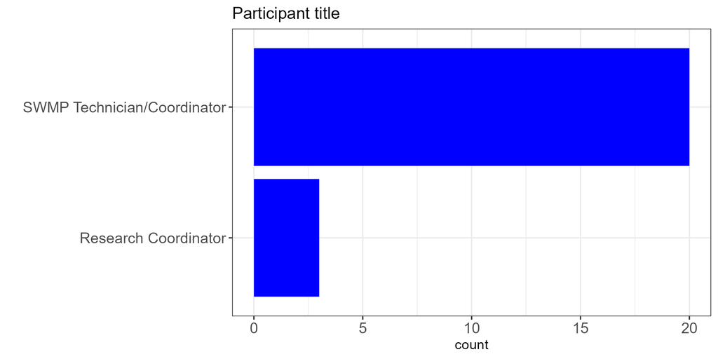

## Goals in the room

. . .

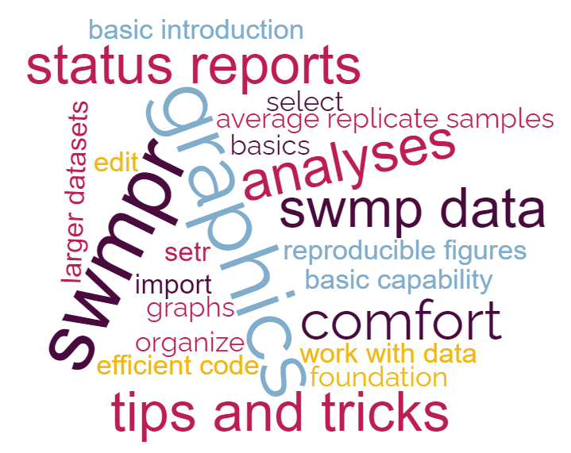

## Commonalities

No matter what you want to do, you need to get comfortable with a few basics first:

- Getting data into R
- Making sure your data frame looks right
- Working with the data:
  - Taking a subset
  - Summarizing
  - Re-shaping
  - Connecting one data frame to another

We’ll be focusing mostly on the first two today.

# Structure for today

## Topics

- Background and vocabulary
- CODING - working with SWMP data
  - learning about the code as we *do* things
  - Sticky notes - pink for “please come help me”; blue for “I successfully accomplished the task”
- Moving forward

## Remember

. . .

[figure not shown]

## And sometimes

. . .

[figure not shown]

## Tips

- Be gentle with yourself
- Be persistent
- Help your neighbor
- Look for commas and parentheses/brackets first - either missing or extra
- Spelling and other punctuation next

Punctuation - mainly parentheses or brackets. RStudio helps a lot with this - tells you when something is wrong (in the left margin), and enabling “rainbow parentheses” in the global options is MAGICAL.

Tools menu – Global Options – Code (from left pane) – Display (a tab in main pane) – Syntax (in the Display tab) – bottom option: “Use rainbow parentheses”

# Understanding code and context

## File Types & getting meta about these slides

(so you can take notes in the R files that generated them, and render a complete document for yourself later)

- .RProj - Project and how to open
- .R - the basic “R script”
- .Rmd - “RMarkdown”
- .qmd - “Quarto”

. . .

[figure not shown]

Notes: demo .R and .qmd files; source/visual editor; and how to render.

## Vocabulary

- function
- package
  - CRAN
  - GitHub
  - others
- project
- working directory and file paths
  - `getwd()`/`setwd()`
  - `here::here()`

## RStudio IDE

- global settings
- panes
- using the Environment pane to explore your workspace

## Key “operators” in code

- assignment operator: `<-`
- pipe: `|>` or `%>%`
- comments: `#`

## Useful keyboard shortcuts

- run a line of code: `Ctrl`/`Cmd` + `Enter`
- make the assignment operator (`<-`): `Alt` + `-`
- make a pipe (`|>`): `Ctrl`/`Cmd` + `Shift` + `M`
- see more in RStudio’s ‘Tools’ menu; ‘Keyboard Shortcuts Help’

## Subsetting operators

- `$` — `df$column.name`
- `[rows, columns]` — `df[1:6, 1:2]`
- `dplyr::select()` — `select(df, column.name1, column.name2)`
- `dplyr::filter()` — `filter(df, year >= 2015)`